# Lab 08 - Text Mining/NLP

# Learning goals

- Use `unnest_tokens()` and `unnest_ngrams()` to extract tokens and ngrams from text
- Use dplyr and ggplot2 to analyze and visualize text data
- Try a theme model using `topicmodels`

# Lab description

For this lab we will be working with the medical record transcriptions from https://www.mtsamples.com/ available at https://github.com/JSC370/JSC370-2025/tree/main/data/medical_transcriptions.

# Deliverables

1. Questions 1-7 answered, knit to pdf or html output uploaded to Quercus.
2. Render the Rmarkdown document using `github_document` and add it to your github site. Add link to github site in your html.

### Setup packages

You should load in `tidyverse`, (or `data.table`), `tidytext`, `wordcloud2`, `tm`, and `topicmodels`.

```r
# install.packages(c("tidyverse", "tidytext", "wordcloud2", "topicmodels"))
# install.packages("tm", dependencies=TRUE)
# install.packages("stopwords")
```

## Read in the Medical Transcriptions

Loading in reference transcription samples from https://www.mtsamples.com/

```r
library(tidytext)
library(tidyverse)
library(wordcloud2)
library(tm)
library(topicmodels)
library(stopwords)
library(ggplot2)

mt_samples <- read_csv("https://raw.githubusercontent.com/JSC370/JSC370-2025/main/data/medical_transcriptions/mtsamples.csv")
mt_samples <- mt_samples |>
  select(description, medical_specialty, transcription)

head(mt_samples)
```

```
## # A tibble: 6 × 3
##   description                                    medical_specialty transcription
##   <chr>                                          <chr>             <chr>
## 1 A 23-year-old white female presents with comp… Allergy / Immuno… "SUBJECTIVE:…
## 2 Consult for laparoscopic gastric bypass.       Bariatrics        "PAST MEDICA…
## 3 Consult for laparoscopic gastric bypass.       Bariatrics        "HISTORY OF …
## 4 2-D M-Mode. Doppler.                           Cardiovascular /… "2-D M-MODE:…
## 5 2-D Echocardiogram                             Cardiovascular /… "1.  The lef…
## 6 Morbid obesity.  Laparoscopic antecolic anteg… Bariatrics        "PREOPERATIV…
```

## Question 1: What specialties do we have?

We can use `count()` from `dplyr` to figure out how many different medical specialties are in the data. Are these categories related? overlapping? evenly distributed? Make a bar plot.

```
## [1] 30
```

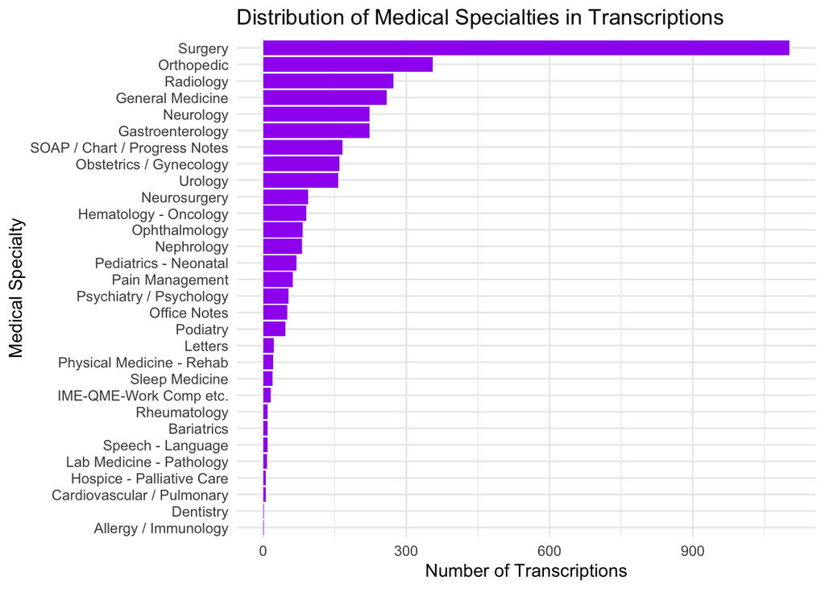

```r
mt_samples |>
  count(medical_specialty, sort = TRUE) |>
  ggplot(aes(x = reorder(medical_specialty, n), y = n)) +
  geom_col(fill = "purple") +
  coord_flip() +
  labs(
    title = "Distribution of Medical Specialties in Transcriptions",
    x = "Medical Specialty",
    y = "Number of Transcriptions"
  ) +
  theme_minimal()

mt_samples |>
  distinct(medical_specialty) |>
  nrow()
```

There are 30 different medical specialties. They don’t seem to be evenly distributed by the bar plot, as we can see that Surgery has the most/highest frequency with more than 900 transcriptions. The rest have only range from 0 to more than 300 transcriptions.

## Question 2: Tokenize

- Tokenize the the words in the `transcription` column
- Count the number of times each token appears
- Visualize the top 20 most frequent words with a bar plot
- Create a word cloud of the top 20 most frequent words

### Explain what we see from this result. Does it makes sense? What insights (if any) do we get?

[interactive chart not shown]

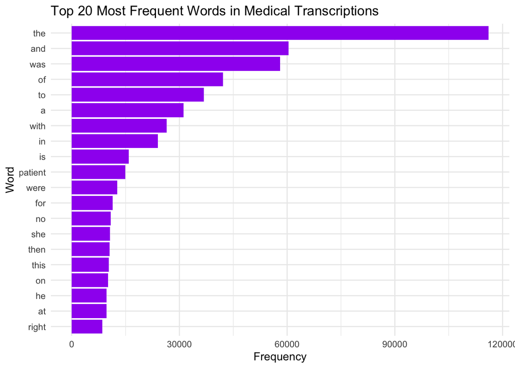

```r
tokens <- mt_samples |>
  select(transcription) |>
  unnest_tokens(word, transcription) |>
  count(word, sort = TRUE)

tokens |>
  slice_max(n, n = 20) |>
  ggplot(aes(x = reorder(word, n), y = n)) +
  geom_bar(stat = "identity", fill = "purple") +
  coord_flip() +
  labs(
    title = "Top 20 Most Frequent Words in Medical Transcriptions",
    x = "Word",
    y = "Frequency"
  ) +
  theme_minimal()

tokens |>
  slice_max(n, n = 20) |>
  wordcloud2()
```

We see that top 20 words don’t make sense; “the”, “and”, “was”, “of” and so on, they’re stopwords rather than medical terms/words. Right now, we don’t have much insights because of the stopwords.

## Question 3: Stopwords

- Redo Question 2 but remove stopwords
- Check `stopwords()` library and `stop_words` in `tidytext`
- Use regex to remove numbers as well
- Try customizing your stopwords list to include 3-4 additional words that do not appear informative

### What do we see when you remove stopwords and then when you filter further? Does it give us a better idea of what the text is about?

```r
head(stopwords("english"))
```

```
## [1] "i"      "me"     "my"     "myself" "we"     "our"
```

```r
length(stopwords("english"))
```

```
## [1] 175
```

```r
head(stop_words)
```

```
## # A tibble: 6 × 2
##   word      lexicon
##   <chr>     <chr>
## 1 a         SMART
## 2 a's       SMART
## 3 able      SMART
## 4 about     SMART
## 5 above     SMART
## 6 according SMART
```

[interactive chart not shown]

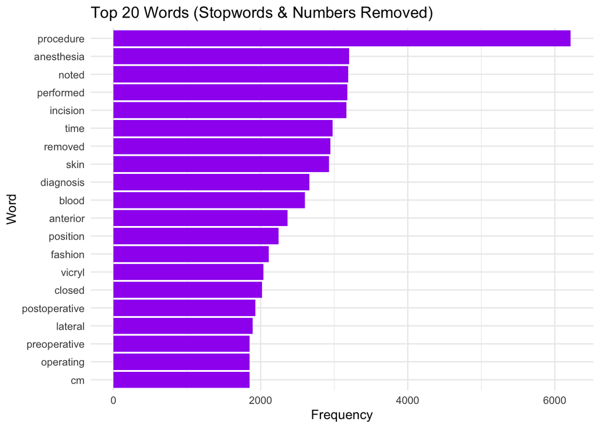

```r
custom_stopwords <- c("patient", "history", "medical", "normal", "left", "mm", "mg", "pain")

tokens <- mt_samples |>
  select(transcription) |>
  unnest_tokens(word, transcription) |>
  filter(!word %in% stop_words$word) |>  # Remove common stopwords
  filter(!word %in% stopwords("english")) |>  # Remove additional stopwords
  filter(!str_detect(word, "^[0-9]+$")) |>  # Remove numbers
  filter(!word %in% custom_stopwords) |>
  count(word, sort = TRUE)

tokens |>
  slice_max(n, n = 20) |>
  ggplot(aes(x = reorder(word, n), y = n)) +
  geom_bar(stat = "identity", fill = "purple") +
  coord_flip() +
  labs(
    title = "Top 20 Words (Stopwords & Numbers Removed)",
    x = "Word",
    y = "Frequency"
  ) +
  theme_minimal()

tokens |>
  slice_max(n, n = 20) |>
  wordcloud2()
```

After removing stopwords and numbers, the result makes more sense because words like “the,” “and,” “was”, “of” etc. no longer dominate the results. We can see more medical terms appear. This gives us a better understanding of the transcriptions. Also, removing extra words like “patient”, “history”, and I did remove some measurements (mm, mg) and others helps highlight other important terms that provide more insight into the text, like now we see vicryl, lateral, incision, anesthesia, etc.

## Question 4: ngrams

Repeat question 2, but this time tokenize into bi-grams. How does the result change if you look at tri-grams? Note we need to remove stopwords a little differently. You don’t need to recreate the wordclouds.

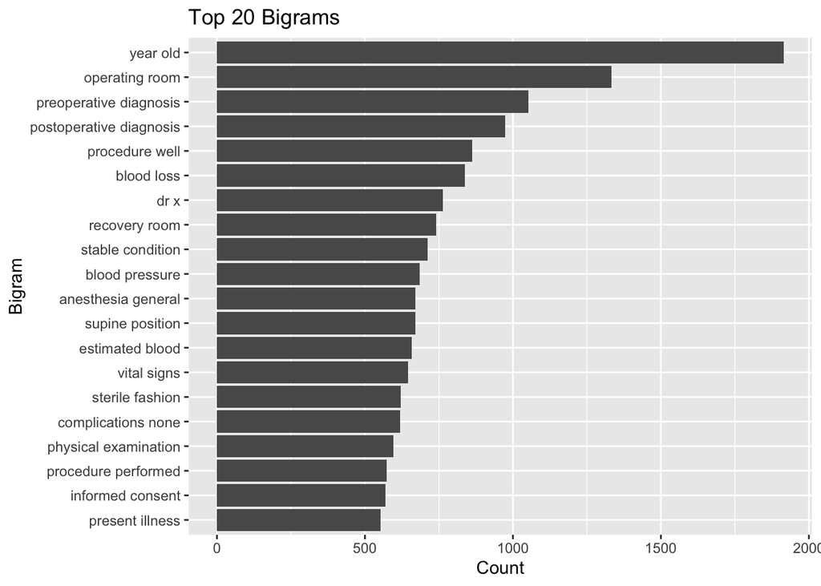

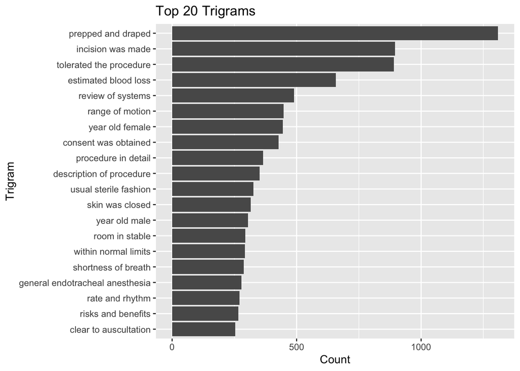

```r
stopwords2 <- c(stopwords::stopwords("en"), custom_stopwords)

sw_start <- paste0("^", paste(stopwords2, collapse=" |^"), "$")
sw_end <- paste0("", paste(stopwords2, collapse="$| "), "$")

tokens_bigram <- mt_samples |>
  select(transcription) |>
  unnest_tokens(ngram, transcription, token = "ngrams", n = 2) |>
  filter(!str_detect(ngram, sw_start)) |>
  filter(!str_detect(ngram, sw_end)) |>
  filter(!str_detect(ngram, "\\d+"))

tokens_bigram |>
  count(ngram, sort = TRUE) |>
  slice_max(n, n = 20) |>
  ggplot(aes(x = reorder(ngram, n), y = n)) +
  geom_bar(stat = "identity") +
  coord_flip() +
  labs(title = "Top 20 Bigrams", x = "Bigram", y = "Count")

tokens_trigram <- mt_samples |>
  select(transcription) |>
  unnest_tokens(ngram, transcription, token = "ngrams", n = 3) |>
  filter(!str_detect(ngram, sw_start)) |>
  filter(!str_detect(ngram, sw_end)) |>
  filter(!str_detect(ngram, "\\d+"))

tokens_trigram |>
  count(ngram, sort = TRUE) |>
  slice_max(n, n = 20) |>
  ggplot(aes(x = reorder(ngram, n), y = n)) +
  geom_bar(stat = "identity") +
  coord_flip() +
  labs(title = "Top 20 Trigrams", x = "Trigram", y = "Count")
```

## Question 5: Examining words

Using the results from the bigram, pick a word and count the words that appear before and after it, and create a plot of the top 20.

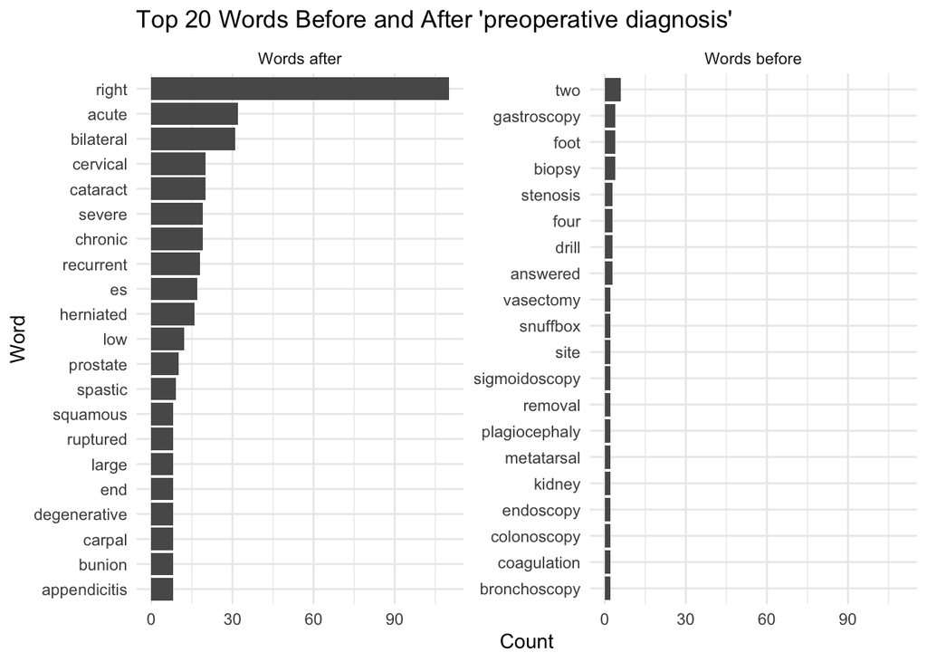

```r
library(stringr)

words_before <- tokens_trigram |>
  filter(str_detect(ngram, "\\w+ preoperative diagnosis")) |>
  mutate(word = str_remove(ngram, " preoperative diagnosis.*"),
         word = str_remove_all(word, "[[:punct:]]"),
         position = "Words before") |>
  count(word, position, sort = TRUE) |>
  slice_max(n, n = 20)

words_after <- tokens_trigram |>
  filter(str_detect(ngram, "preoperative diagnosis \\w+")) |>
  mutate(word = str_remove(ngram, ".*preoperative diagnosis "),
         word = str_remove_all(word, "[[:punct:]]"),
         position = "Words after") |>
  count(word, position, sort = TRUE) |>
  slice_max(n, n = 20)

words_combined <- bind_rows(words_before, words_after)

words_combined |>
  ggplot(aes(x = reorder(word, n), y = n)) +
  geom_bar(stat = "identity") +
  coord_flip() +
  facet_wrap(~ position, scales = "free_y") +
  labs(title = "Top 20 Words Before and After 'preoperative diagnosis'",
       x = "Word",
       y = "Count") +
  theme_minimal()
```

## Question 6: Words by Specialties

Which words are most used in each of the specialties? You can use `group_by()` and `top_n()` from `dplyr` to have the calculations be done within each specialty. Remember to remove stopwords. How about the 5 most used words?

```r
# most used in each
mt_samples |>
  unnest_tokens(word, transcription) |>
  filter(!word %in% stop_words$word) |>
  filter(!word %in% stopwords("english")) |>
  filter(!str_detect(word, "^[0-9]+$")) |>
  filter(!word %in% custom_stopwords) |>
  count(medical_specialty, word, sort = TRUE) |>
  group_by(medical_specialty) |>
  top_n(1) |>
  ungroup()
```

```
## # A tibble: 34 × 3
##    medical_specialty       word          n
##    <chr>                   <chr>     <int>
##  1 Surgery                 procedure  3243
##  2 Orthopedic              procedure   669
##  3 Ophthalmology           eye         456
##  4 Gastroenterology        procedure   455
##  5 General Medicine        blood       407
##  6 Urology                 bladder     357
##  7 Obstetrics / Gynecology uterus      317
##  8 Radiology               exam        302
##  9 Neurosurgery            c5          289
## 10 Neurology               time        278
## # ℹ 24 more rows
```

```r
# top 5
mt_samples |>
  unnest_tokens(word, transcription) |>
  filter(!word %in% stop_words$word) |>
  filter(!word %in% stopwords("english")) |>
  filter(!str_detect(word, "^[0-9]+$")) |>
  filter(!word %in% custom_stopwords) |>
  count(medical_specialty, word, sort = TRUE) |>
  group_by(medical_specialty) |>
  top_n(5) |>
  arrange(medical_specialty, desc(n))
```

```
## # A tibble: 174 × 3
## # Groups:   medical_specialty [30]
##    medical_specialty    word             n
##    <chr>                <chr>        <int>
##  1 Allergy / Immunology allergies        4
##  2 Allergy / Immunology allegra          3
##  3 Allergy / Immunology prescription     3
##  4 Allergy / Immunology sprays           3
##  5 Allergy / Immunology erythematous     2
##  6 Allergy / Immunology medication       2
##  7 Allergy / Immunology nasal            2
##  8 Allergy / Immunology weeks            2
##  9 Allergy / Immunology zyrtec           2
## 10 Bariatrics           abdomen         20
## # ℹ 164 more rows
```

We can see some of the medical specialties has most used word “procedure”. Others seem expected like the name of the medical specialty (ex. Urology has “bladder” and Gynecology has “uterus).

## Question 7: Topic Models

See if there are any themes in the data by using a topic model (LDA).

- you first need to create a document term matrix
- then you can try the LDA function in `topicmodels`. Try different k values.
- create a facet plot of the results from the LDA (see code from lecture)

```r
install.packages("reshape2")
```

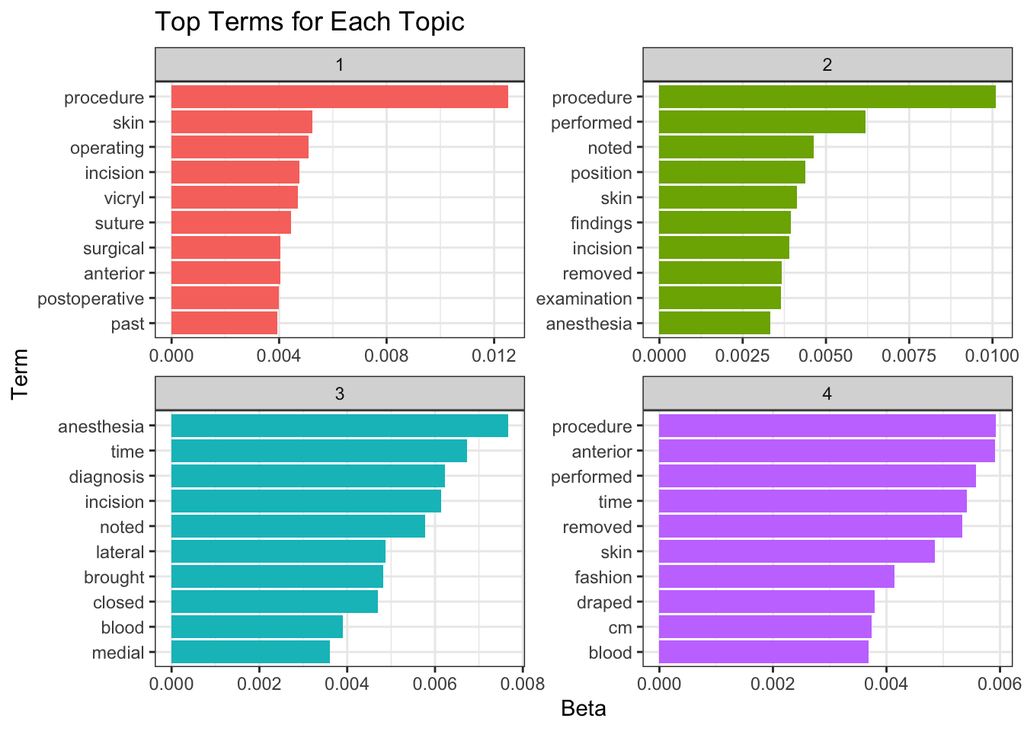

```r
transcripts_dtm <- mt_samples |>
  select(transcription) |>
  unnest_tokens(word, transcription) |>
  filter(!word %in% stop_words$word) |>
  filter(!word %in% stopwords("english")) |>
  filter(!str_detect(word, "^[0-9]+$")) |>
  filter(!word %in% custom_stopwords) |>
  count(document = row_number(), word) |>
  cast_dtm(document, word, n)

transcripts_lda <- LDA(transcripts_dtm, k = 4, control = list(seed = 1234))

lda_top_terms <- tidy(transcripts_lda, matrix = "beta") |>
  group_by(topic) |>
  slice_max(beta, n = 10) |>    # Select top 10 terms per topic
  ungroup() |>
  arrange(topic, -beta)

lda_top_terms |>
  mutate(term = reorder_within(term, beta, topic)) %>%
  ggplot(aes(beta, term, fill = factor(topic))) +
  geom_col(show.legend = FALSE) +
  facet_wrap(~ topic, scales = "free") +
  theme_bw() +
  scale_y_reordered() +
  labs(title = "Top Terms for Each Topic", x = "Beta", y = "Term")
```

Here I do 4 topics. In each we can see the top 10 terms.